## MA2102

# Probability and Statistics

#### Lecture-21

## Conditional Expectation:

Let $(X,Y)$ be a bivariate random variable then conditional expectation of $g(X,Y)$ given $Y=y$ is denoted by $E(g(X,Y)/Y=y)$ and defined as (provided sum/integral converges absolutely)

$E(g(X,Y)/Y=y)=\left\{\begin{matrix} \underset{x\in S_X}{\sum}g(x,y)p_{X/Y}(x/y)& \text{if } (X,Y) \text{ is of discrete type and } p_Y(y)>0 \\ \int_{-\infty}^{\infty}g(x,y)f_{X/Y}(x/y)dx& \text{if } (X,Y) \text{ is of continuous type and } f_Y(y)>0 \end{matrix}\right.$

similarly you can define $E(g(X,Y)/X=x)$

**Example:** Let $(X,Y)$ be a continuous bivariate random variable with $JPDF$, $f_{X,Y}(x,y)=\left\{\begin{matrix} \frac{e^{-\frac{x}{y}}e^{-y}}{y}&x>0,y>0 \\ 0& \text{otherwise} \end{matrix}\right.$. Compute $E(X/Y=y)$

*solution:* $f_Y(y)=\int_{-\infty}^{\infty}f_{X,Y}(x,y)dx=\int_{0}^{\infty} \frac{e^{-\frac{x}{y}}e^{-y}}{y}dx$

$=\frac{e^{-y}}{y}\int_{0}^{\infty}e^{-\frac{x}{y}}dx=\frac{e^{-y}}{y}\left[\frac{e^{-\frac{x}{y}}}{-\frac{1}{y}}\right]_0^\infty=e^{-y}$

$f_{X/Y}(x/y)=\frac{e^{-\frac{x}{y}}e^{-y}}{\frac{y}{e^{-y}}}=\frac{1}{y}e^{-\frac{x}{y}}$, for $x>0$

$E(X/Y=y)=\int_{0}^{\infty}xf_{X/Y}\left(x/y\right)dx=\int_{0}^{\infty}x\left(\frac{1}{y}e^{-\frac{x}{y}}\right)dx$

$=y\int_{0}^{\infty}\left(\frac{x}{y}e^{-\frac{x}{y}}\right)\frac{dx}{y}dx$ Take $t=\frac{x}{y}\implies~dt=\frac{dx}{y}$

$=y\int_{0}^{\infty}te^{-t}dt=y\int_{0}^{\infty}t^{2-1}e^{-t}dt=y\Gamma(2)=y(1!)$

$\therefore$ $E(X/Y=y)=y$

- $E(g(X,Y)/Y)$ will take the values $E(g(X,Y)/Y=y)$, $y\in S_Y$. So, $E(g(X,Y)/Y)$ can be seen as function of random variable $Y$

Similarly $E(g(X,Y)/X)$ is function of random variable $X$

**Note:**

1. $E(g(X,Y))=E(E(g(X,Y)/Y))$

*proof:* We will show it when $(X,Y)$ is continuous type

$E(g(X,Y))=\int_{-\infty}^{\infty}\int_{-\infty}^{\infty}g(x,y)f_{X,Y}(x,y)dxdy$

$=\int_{-\infty}^{\infty}\left[\int_{-\infty}^{\infty}g(x,y)\frac{f_{X,Y}(x,y)dx}{f_Y(y)}\right]f_Y(y)dy$

$=\int_{-\infty}^{\infty}\left[\int_{-\infty}^{\infty}g(x,y){f_{X/Y}(x/y)dx}\right]f_Y(y)dy$

$=\int_{-\infty}^{\infty}E(g(X,Y)/Y=y)f_Y(y)dy=E(E(g(X,Y)/Y))$

similarly you can show that, $E(g(X,Y))=E(E(g(X,Y)/X))$

1. $Var(g(X,Y))=E(Var(g(X,Y)/Y))+Var(E(g(X,Y)/Y))$

*proof:* $Var(g(X,Y)/Y)=E(g(X,Y)^2/Y)-\left(E(g(X,Y)/Y)\right)^2$

$E(Var(g(X,Y)/Y))=E\left(E(g(X,Y)^2/Y)\right)-E\left(\left(E(g(X,Y)/Y)\right)^2\right)$

$E(Var(g(X,Y)/Y))=E\left(g(X,Y)^2\right)-E\left(\left(E(g(X,Y)/Y)\right)^2\right)$ ($\because$ Note 1) ------(A)

$Var(\left(E(g(X,Y)/Y\right))=E\left(\left(E(g(X,Y)/Y\right)^2\right)-\left(E\left(E(g(X,Y)/Y\right)\right)^2$

$Var(\left(E(g(X,Y)/Y\right)=E\left(\left(E(g(X,Y)/Y\right)^2\right)-(E(g(X,Y))^2$ ($\because$ Note 1) ------(B)

(A)+(B) $\implies$ $E(Var(g(X,Y)/Y))+Var(\left(E(g(X,Y)/Y\right)=E\left(g(X,Y)^2\right)-(E(g(X,Y))^2=Var(g(X,Y))$

$\therefore~Var(g(X,Y))=E(Var(g(X,Y)/Y))+Var(\left(E(g(X,Y)/Y\right)$

similarly you can show that, $Var(g(X,Y))=E(Var(g(X,Y)/X))+Var(\left(E(g(X,Y)/X\right)$

**Problem:** Suppose that by any time $t$ the number of people that have arrived at a train depot is a Posson random variable with mean $\lambda t$. If the initial train arrives at the depot at a time (independent of when the passengers arrive) that is uniformly distributed over $[0,T]$, what is the mean and variance of the number of passengers that enter the train?

*solution:* Let for each $t\ge 0$,$N(t)$ denote the number of arrivals by the time $t$, and

$Y$ denote the time at which the train arrives.

$N(Y)$ denote the number passengers that arrived at train depot by the time train arrives

Then we are intersted in $E(N(Y))$, and $Var(N(Y))$

Here $Y\sim U[0,T]$, and $N(Y)/Y=t \sim Poisson(\lambda t)$

$E(Y)=\frac{T}{2},~Var(Y)=\frac{T^2}{12}$,and $E(N(Y)/Y)=Var(N(Y)/Y)=\lambda Y$

now, $E(N(Y))=E(E(N(Y)/Y))$ ($\because$ Note (1))

$=E(\lambda Y)=\lambda E(Y)=\lambda \left(\frac{T}{2}\right)$

$\therefore$ $E(N(Y))=\frac{\lambda T}{2}$

$Var(N(Y))=E(Var(N(Y)/Y))+Var(E(N(Y)/Y))$ ($\because$ Note (2))

$=E(\lambda Y)+Var((\lambda Y))=\lambda E(Y)+\lambda ^2Var(Y)=\lambda \left(\frac{T}{2}\right)+\lambda^2\left(\frac{T^2}{12}\right)$

$\therefore$ $Var(N(Y))=\lambda \left(\frac{T}{2}\right)+\lambda^2\left(\frac{T^2}{12}\right)$

## Joint Moment generating function(JMGF):

Let $(X,Y)$ be a bivariate random variable , the $JMGF$ of $(X,Y)$ is defined as,  
$M_{X,Y}(t_1,t_2)=E\left(e^{t_1X+t_2Y}\right)$, provided the expectation exists in neighborhood of $(0,0)$

It is easy to see that $M_{X,Y}(t_1,0)=M_X(t_1)$ & $M_{X,Y}(0,t_2)=M_Y(t_2)$

$JMGF$ of $\underline{X}=(X_1,X_2,...,X_k)$ is $M_{\underline{X}}(t)=E\left(e^{\sum_{i=1}^kt_iX_i}\right)$ provided the expectation exists in neighborhood of $(0,0,...,0)\in \mathbb{R}^k$

**Example:** Let $(X,Y)$ be a continuous bivariate random variable with $JPDF$, $f_{X,Y}(x,y)=\left\{\begin{matrix} e^{-y}& 0<x<y<\infty \\ 0& \text{otherwise} \end{matrix}\right.$

$M_{X,Y}(t_1,t_2)=\int_{-\infty}^{\infty}\int_{-\infty}^{\infty}e^{t_1x+t_2y}f_{X,Y}(x,y)dxdy$

$=\int_{0}^{\infty}\int_{x}^{\infty}e^{t_1x}e^{t_2y}e^{-y}dxdy=\int_{0}^{\infty}e^{t_1x}\left[\int_{x}^{\infty}e^{(t_2-1)y}dy\right]dx$

$=\int_{0}^{\infty}e^{t_1x}\left[\frac{e^{(t_2-1)y}}{t_2-1}\right]_x^\infty dx$

for $t_2<1$ $\lim_{y\to\infty}\frac{e^{(t_2-1)y}}{t_2-1}=0$

$\frac{1}{(t_2-1)}\int_{0}^{\infty}e^{t_1x}\left[0-e^{(t_2-1)x}\right]dx=-\frac{1}{(t_2-1)}\int_{0}^{\infty}e^{(t_1+t_2-1)x}dx$

$=-\frac{1}{(t_2-1)}\left[\frac{e^{(t_1+t_2-1)x}}{(t_1+t_2-1)}\right]_0^\infty$

for $t_1+t_2<1$, $\lim_{x\to\infty}\frac{e^{(t_1+t_2-1)x}}{(t_1+t_2-1)}=0$

$M_{X,Y}(t_1,t_2)=\frac{1}{(1-t_2)(1-t_1-t_2)}$, $t_1+t_2<1,t_2<1$

Further, $MGF$ of $X$, $M_X(t_1)=M_{X,Y}(t_1,0)=\frac{1}{(1-0)(1-t_1-0)}=\frac{1}{1-t_1}$, $t_1<1$

$MGF$ of $Y$, $M_Y(t_2)=M_{X,Y}(0,t_2)=\frac{1}{(1-t_2)(1-0-t_2)}=\frac{1}{(1-t_2)^2}$, $t_2<1$

Looking at $M.G.F's$ we can say that $X\sim Exp(1)$ & $Y\sim Gamma(2,1)$

### Finding product moments through $JMGF$

$M_{X,Y}(t_1,t_2)=E(e^{t_1X+t_2Y})$

$\frac{\partial^{r+s}M_{X,Y}(t_1,t_2)}{\partial t_1^r \partial t_2^s}=E\left(\frac{\partial^{r+s}e^{t_1X+t_2Y}}{\partial t_1^r \partial t_2^s}\right)$$=E(X^rY^se^{t_1X+t_2Y})$

$\frac{\partial^{r+s}M_{X,Y}(0,0)}{\partial t_1^r \partial t_2^s}=E(X^rY^s)=\mu_{r,s}^{'}$

$\mu_X=E(X)=\mu_{1,0}^{'}=\frac{\partial M_{X,Y}(0,0)}{\partial t_1}$, and $\mu_Y=E(Y)=\mu_{0,1}^{'}=\frac{\partial M_{X,Y}(0,0)}{\partial t_2}$

$\sigma_X^2=Var(X)=E(X^2)-(E(X))^2=\frac{\partial^{2}M_{X,Y}(0,0)}{\partial t_1^2}-\left(\frac{\partial M_{X,Y}(0,0)}{\partial t_1}\right)^2$

$\sigma_Y^2=Var(Y)=E(Y^2)-(E(Y))^2=\frac{\partial^{2}M_{X,Y}(0,0)}{\partial t_2^2}-\left(\frac{\partial M_{X,Y}(0,0)}{\partial t_2}\right)^2$

$\mu_{XY}=E(XY)=\frac{\partial^{2}M_{X,Y}(0,0)}{\partial t_1 \partial t_2}$

$Cov(X,Y)=E(XY)-E(X)E(Y)$

$Cov(X,Y)=\frac{\partial^{2}M_{X,Y}(0,0)}{\partial t_1 \partial t_2}-\frac{\partial M_{X,Y}(0,0)}{\partial t_1}\frac{\partial M_{X,Y}(0,0)}{\partial t_2}$

**Theorem:** $X,Y$ are independent $\iff$ $M_{X,Y}(t_1,t_2)=M_X(t_1)M_Y(t_2)$ $\forall (t_1,t_2)\in \mathbb{R}^2$

*proof:* Let $X,Y$ are independent

$M_{X,Y}(t_1,t_2)=E\left(e^{t_1X+t_2Y}\right)$

$=E\left(e^{t_1X}.e^{t_2Y}\right)$

$=E\left(e^{t_1X}\right)E\left(e^{t_2Y}\right)$ ($\because$ $E(g(X)h(Y))=E(g(X))E(h(Y))$ when $X,Y$ are independent)

$\therefore$ $M_{X,Y}(t_1,t_2)=M_X(t_1)M_Y(t_2)$

Converse also true but we are not proving it here.

**Theorem:** $X_1,X_2,...,X_k$ are independent $\iff$ $M_{\underline{X}}(t_1,t_2,...,t_k)=\prod_{i=1}^kM_{X_i}(t_i)$, where $\underline{X}=(X_1,X_2,...,X_k)$

**Theorem:** If $X,Y$ are independent then $M_{X+Y}(t)=M_X(t)M_Y(t)~\forall t\in mathbb{R}$

*proof:* $M_{X+Y}(t)=E(e^{t(X+Y)})$

$=E(e^{tX}e^{tY})=E(e^{tX})E(e^{tY})$ ($\because$ $X,Y$ are independent)

$\therefore$ $M_{X+Y}(t)=M_X(t)M_Y(t)$

**Corollary:** If $X_1,X_2,...,X_k$ are independent then $M_{\sum_{i=1}^kX_i}(t)=\prod_{i=1}^kM_{X_i}(t)$,

**Theorem:** Let $X_1,X_2,...,X_k$ are independent and $X_i\sim Bin(n_i,p)$ for $i=1,2,...k$, then $\sum_{i=1}^kX_i\sim Bin(\sum_{i=1}^kn_i,p)$

*proof:* $X_i\sim Bin(n_i,p)\implies$ $M_{X_i}(t)=(1-p+pe^t)^{n_i}$ for $i=1,2,...,k$

$M_{\sum_{i=1}^kX_i}(t)=\prod_{i=1}^kM_{X_i}(t)$ ($\because$ $X_1,X_2,...,X_k$ are independent )

$=\prod_{i=1}^k(1-p+pe^t)^{n_i}=(1-p+pe^t)^{\sum_{i=1}^kn_i}$

Looking at $MGF$ of $\sum_{i=1}^kX_i$ we can say that $\sum_{i=1}^kX_i\sim Bin(\sum_{i=1}^kn_i,p)$

**Corollary:** If $X_1,X_2,...,X_k$ are independent, $X_i\sim Bern(p)$(i.e $X_i\sim Bin(1,p)$) for $i=1,2,...k$, then $\sum_{i=1}^kX_i\sim Bin(k,p)$

**Theorem:** Let $X_1,X_2,...,X_k$ are independent and $X_i\sim Poisson(\lambda_i)$ for $i=1,2,...k$, then $\sum_{i=1}^kX_i\sim Poisson(\sum_{i=1}^k\lambda_i)$

*proof:* $X_i\sim Piosson(\lambda_i)\implies$ $M_{X_i}(t)=e^{\lambda_i(e^t-1)}$ for $i=1,2,...,k$

$M_{\sum_{i=1}^kX_i}(t)=\prod_{i=1}^kM_{X_i}(t)$ ($\because$ $X_1,X_2,...,X_k$ are independent )

$=\prod_{i=1}^ke^{\lambda_i(e^t-1)}=e^{(\sum_{i=1}^k\lambda_i)(e^t-1)}$

$\therefore sum_{i=1}^kX_i\sim Poisson(\sum_{i=1}^k\lambda_i)$

**Theorem:** Let $X_1,X_2,...,X_k$ are independent and $X_i\sim NB(r_i,p)$ for $i=1,2,...k$, then $\sum_{i=1}^kX_i\sim NB(\sum_{i=1}^kr_i,p)$

*proof:* $X_i\sim NB(r_i,p)\implies$ $M_{X_i}(t)=\left(\frac{p}{1-p+pe^t}\right)^{r_i}$ for $i=1,2,...,k$

$M_{\sum_{i=1}^kX_i}(t)=\prod_{i=1}^kM_{X_i}(t)$ ($\because$ $X_1,X_2,...,X_k$ are independent )

$=\prod_{i=1}^k\left(\frac{p}{1-p+pe^t}\right)^{r_i}=\left(\frac{p}{1-p+pe^t}\right)^{\sum_{i=1}^kr_i}$

$\therefore \sum_{i=1}^kX_i\sim NB(\sum_{i=1}^kr_i,p)$

**Corollary:** Let $X_1,X_2,...,X_k$ are independent and $X_i\sim Geom(p)$ (i.e $X_i\sim NB(1,p)$) for $i=1,2,...k$, then $\sum_{i=1}^kX_i\sim NB(k,p)$

**Theorem:** Let $X_1,X_2,...,X_k$ are independent and $X_i\sim Gamma(\alpha_i,\lambda)$ for $i=1,2,...k$, then $\sum_{i=1}^kX_i\sim Gamma(\sum_{i=1}^k\alpha_i,\lambda)$

*proof:* $X_i\sim Gamma(\alpha_i,\lambda)\implies$ $M_{X_i}(t)=\left(\frac{\lambda}{\lambda-t}\right)^{\alpha_i}$ for $i=1,2,...,k$

$M_{\sum_{i=1}^kX_i}(t)=\prod_{i=1}^kM_{X_i}(t)$ ($\because$ $X_1,X_2,...,X_k$ are independent )

$=\prod_{i=1}^k\left(\frac{\lambda}{\lambda-t}\right)^{\alpha_i}=\left(\frac{\lambda}{\lambda-t}\right)^{\sum_{i=1}^k\alpha_i}$

$\therefore \sum_{i=1}^kX_i\sim Gamma(\sum_{i=1}^k\alpha_i,\lambda)$

**Corollary:** Let $X_1,X_2,...,X_k$ are independent and $X_i\sim Exp(\lambda)$ (i.e $X_i\sim Gamma(1,\lambda)$)for $i=1,2,...k$, then $\sum_{i=1}^kX_i\sim Gamma(k,\lambda)$

**Theorem:** Let $X_1,X_2,...,X_k$ are independent and $X_i\sim N(\mu_i,\sigma_i^2)$ for $i=1,2,...k$, then $\sum_{i=1}^kX_i\sim N(\sum_{i=1}^k\mu_i,\sum_{i=1}^k\sigma_i^2)$

*proof:* $X_i\sim N(\mu_i,\sigma_i^2)\implies$ $M_{X_i}(t)=e^{\mu_it+\frac{1}{2}\sigma_i^2t^2}$ for $i=1,2,...,k$

$M_{\sum_{i=1}^kX_i}(t)=\prod_{i=1}^kM_{X_i}(t)$ ($\because$ $X_1,X_2,...,X_k$ are independent )

$=\prod_{i=1}^ke^{\mu_it+\frac{1}{2}\sigma_i^2t^2}=e^{(\sum_{i=1}^k\mu_i)t+\frac{1}{2}(\sum_{i=1}^k\sigma_i^2)t^2}$

$\therefore \sum_{i=1}^kX_i\sim N(\sum_{i=1}^k\mu_i,\sum_{i=1}^k\sigma_i^2)$

**Corollary :** Let $X_1,X_2,...,X_k$ are independent and $X_i\sim N(\mu_i,\sigma_i^2)$ for $i=1,2,...k$, then $\sum_{i=1}^k(a_iX_i+b_i)\sim N(\sum_{i=1}^k(a_i\mu_i+b_i),\sum_{i=1}^ka_i^2\sigma_i^2)$

**Problem:** Find the $PDF$ of $X=Z^2$ where $Z\sim N(0,1)$

$PDF$ of $Z$, $\varphi(z)=\frac{1}{\sqrt{2\pi}}e^{-\frac{z^2}{2}}$,$-\infty<z<\infty$

$f_X(x)=\frac{\varphi(\sqrt{x})}{\sqrt{x}}$ ($\because~\varphi(x)$ is even function)

$=\frac{1}{\sqrt{2\pi}}\frac{e^{-\frac{x}{2}}}{\sqrt{x}}=\frac{1}{\sqrt{\pi}}\frac{1}{2}\left(\frac{x}{2}\right)^{\frac{1}{2}-1}e^{-\frac{x}{2}}$

$\therefore$ $f_X(x)=\left\{\begin{matrix} \frac{\frac{1}{2}\left(\frac{x}{2}\right)^{\frac{1}{2}-1}e^{-\frac{x}{2}}}{\Gamma\left(\frac{1}{2}\right)}& x>0\\ 0& x\le 0 \end{matrix}\right.$

$\therefore$ $X\sim Gamma(\frac{1}{2},\frac{1}{2})$

We can re-write the $PDF$ of $X$, $f_X(x)=\left\{\begin{matrix} \frac{1}{2^{\frac{1}{2}}\Gamma\left(\frac{1}{2}\right)}x^{\frac{1}{2}-1}e^{-\frac{x}{2}}& x>0\\ 0& x\le 0 \end{matrix}\right.$

Here $X$ is said to have **Chi-Squared distribution with 1-degree of freedom**

**Notation:** $X\sim \chi^2_1$

**Theorem:** Let $X_1,X_2,...,X_k$ are independent and $X_i\sim \chi^2(1)$ (i.e $X_i\sim Gamma(\frac{1}{2},\frac{1}{2})$) for $i=1,2,...k$, then $\sum_{i=1}^kX_i\sim Gamma(\frac{k}{2},\frac{1}{2})$

A $Gamma(\frac{k}{2},\frac{1}{2})$ distribution is called **Chi-Squared distribution with k-degrees of freedom**

**Definition:** If $X\sim Gamma(\frac{n}{2},\frac{1}{2})$, then $X$ is said to have Chi-Square distribution with $n$ degrees of freedom

and $PDF$ of $X$, $f_X(x)=\left\{\begin{matrix} \frac{1}{2^{\frac{n}{2}}\Gamma\left(\frac{n}{2}\right)}x^{\frac{n}{2}-1}e^{-\frac{x}{2}}& x>0\\ 0& x\le 0 \end{matrix}\right.$

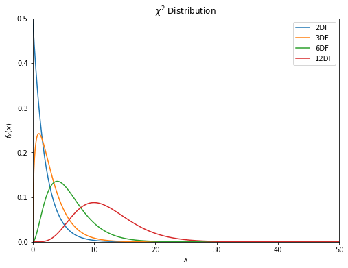

```python
import math
import numpy as np
import matplotlib.pyplot as plt
%matplotlib inline

Infty=50
x=np.linspace(0,Infty,1000)
plt.figure(figsize=(8,6))
dfs = [2,3,6,12] # degree of freedoms
for k in dfs:
    # ploting thw pdf of Chi-squared distribution with k degrees of freedom
    plt.plot(x,((1/2)*np.exp(-x/2)*(x/2)**(k/2-1))/(math.gamma(k/2)),label=r"{0}DF".format(k))
plt.legend(loc='upper right')
plt.title(r"$\chi^2$ Distribution")
plt.xlabel("$x$")
plt.ylabel("$f_X(x)$")
plt.xlim(0,50)
plt.ylim(0,0.5)
plt.show()
```

$CDF$ od $X$, $F_X(x)=\int_0^x \frac{1}{2^{\frac{n}{2}}\Gamma\left(\frac{n}{2}\right)}t^{\frac{n}{2}-1}e^{-\frac{t}{2}}dt$

**Notation:** $X\sim \chi^2_n$

$E(X)=\frac{\frac{n}{2}}{\frac{1}{2}}=n$

$Var(X)=\frac{\frac{n}{2}}{\left(\frac{1}{2}\right)^2}=2n$

$M_X(t)=\left(\frac{\frac{1}{2}}{\frac{1}{2}-t}\right)^{\frac{n}{2}}=\left(\frac{1}{1-2t}\right)^{\frac{n}{2}}$

$\therefore$ $E(\chi^2_n)=n$, $Var(\chi^2_n)=2n$, and $M_{\chi^2_n}(t)=\left(\frac{1}{1-2t}\right)^{\frac{n}{2}}$ for $-\frac{1}{2}<t<\frac{1}{2}$

**Note:** If $X\sim \chi^2_{n_1}, Y\sim \chi^2_{n_2}$ and independent then $X+Y\sim \chi^2_{n_1+n_2}$ ($\because $ sum of independent Gamma random variable with same rate parameter are again Gamma random variable)

```python
%matplotlib inline
import math
import numpy as np
import matplotlib.pyplot as plt
from ipywidgets import interact ,interactive, fixed, interact_manual
import ipywidgets as widgets
from scipy import stats as st

Infty =40

def AreaUnderChiSquaredPDF(n,x):
    fig, ax = plt.subplots(figsize=(8,6))

    xx=np.linspace(0,Infty,1000)
    X=st.chi2(n)  # Chi squared random variable with n degrees of freedom from scipy.stats
    ax.plot(xx,X.pdf(xx),label=r"{0}DF".format(n)) # poting graph of pdf

    xx=list(np.linspace(0,x,1000))

    ax.fill_between(xx,0,X.pdf(xx),color='g',label=r'$F_X(%s)=%s$'%(x,round(X.cdf(x),4)))
    ax.set_title(r"AREA UNDER THE $\chi^2_n$ PDF CURVE TO THE LEFT OF $x$" )
    ax.set_xlabel(r"$t$")
    ax.set_ylabel(r"$f_{\chi^2}(t)$")
    ax.text(x,-0.02,r'%s'%(x))
    ax.set_xticks([0,20,40])
    ax.set_xlim(0,Infty)
    ax.set_xlim(0,Infty)
    ax.set_ylim(0,0.5)
    ax.legend()
    plt.show()

# Please Click the Run Interact Button to see the Bar graph
interactive(AreaUnderChiSquaredPDF,{'manual':False},n=widgets.IntSlider(min=1, max=50, step=1, value=3,description='$n$ :'),x=widgets.FloatSlider(min=0, max=Infty, step=0.01, value=2,description='$x$ :'))
```

The number $x\in \mathbb{R}$ such that $P(\chi^2_n>x)=\alpha$ is denoted by $\chi^2_{\alpha,n}$, and to find these $\chi^2_{\alpha,n}$ values one has to either use software or refer to Chi-Squared distribution Table (Which can be found any statistics book)

```python
%matplotlib inline
import math
import numpy as np
import matplotlib.pyplot as plt
from ipywidgets import interact ,interactive, fixed, interact_manual
import ipywidgets as widgets
from scipy import stats as st

Infty =40

def Qp(n,alpha):
    fig, ax = plt.subplots(figsize=(8,6))
    X=st.chi2(n)  # Chi squared random variable with k degrees of freedom from scipy.stats
    xx=np.linspace(0,Infty,1000)

    ax.plot(xx,X.pdf(xx),label=r"{0}DF".format(n)) # poting graph of pdf
    xx=np.linspace(X.ppf(1-alpha),Infty,1000)
    ax.fill_between(xx,0,X.pdf(xx),color='y',label=r'$\alpha=%s$'%(round(alpha,4)))

    # X.ppf(p) returns pth quantile of X
    ax.scatter([X.ppf(1-alpha)],[0],s=10,color=(1,0,0),label=r'$\chi^2_{%s,%s}=%s$'%(alpha,n,round(X.ppf(1-alpha),4)))
    ax.set_title(r"AREA UNDER THE $\chi^2_{n}$ PDF CURVE TO THE right OF $\chi^2_{\alpha,n}$" )
    ax.set_xlabel(r"$t$")
    ax.set_ylabel(r"$f_X(t)$")
    ax.set_xlim(0,Infty)
    ax.set_xticks([0,40])
    ax.set_ylim(0,0.5)
    ax.text(X.ppf(1-alpha),-0.02,r'$\chi^2_{%s,%s}$'%(round(alpha,4),n),color=(0,0,1))
    ax.legend()
    plt.show()

# Please Click the Run Interact Button to see the Bar graph
interactive(Qp,{'manual':False},n=widgets.IntSlider(min=1, max=50, step=1, value=3,description='$n$ :'),alpha=widgets.FloatSlider(min=0.005, max=1.0, step=0.005, value=0.005,readout_format=".3f",description=r'$\alpha$ :'))
```

```python
%matplotlib inline
import math
import numpy as np
from IPython.display import display, Markdown,HTML
from scipy import stats as st

def printLine(n):
    sline=""
    for _ in range(n):
        sline=sline+"-"
    display(HTML('<span style="color:blue">{0}</span>'.format(sline)))

nn=[r for r in range(1,31) ]
alphas=[0.995,0.99,0.975,0.95,0.05,0.025,0.01,0.005]
display(Markdown("&nbsp; "*40+"$\\chi^2_{\\alpha,n}$  Table"))
printLine(156)
s="n "
for a in alphas:
    s=s+r"&nbsp; "*7+r"$\alpha$="+str(a)
display(Markdown(s))
#print(98*"-")
printLine(156)
for n in nn:
    X=st.chi2(n)
    s=str(n)
    for a in alphas:
        if(X.ppf(1-a)>=10):
            ss=str(round(X.ppf(1-a),3))
        else:
            if n==1 and a> 0.9:
                ss="{:.7f}".format(X.ppf(1-a))
            else:
                ss=str(round(X.ppf(1-a),4))
        ss=ss+(6-len(str(ss)))*'0'

        if n==1:
            if a> 0.9:
                s= s+"&nbsp; "*6+ss
            else:
                s= s+"&nbsp;"*14+ss
        else:
            s= s+"&nbsp; "*8+ss
    display(Markdown(s))

printLine(156)
```

$\chi^2_{\alpha,n}$ Table

------------------------------------------------------------------------------------------------------------------------------------------------------------

n $\alpha$=0.995 $\alpha$=0.99 $\alpha$=0.975 $\alpha$=0.95 $\alpha$=0.05 $\alpha$=0.025 $\alpha$=0.01 $\alpha$=0.005

------------------------------------------------------------------------------------------------------------------------------------------------------------

1 0.0000393 0.0001571 0.0009821 0.0039321 3.8415 5.0239 6.6349 7.8794

2 0.0100 0.0201 0.0506 0.1026 5.9915 7.3778 9.2103 10.597

3 0.0717 0.1148 0.2158 0.3518 7.8147 9.3484 11.345 12.838

4 0.2070 0.2971 0.4844 0.7107 9.4877 11.143 13.277 14.860

5 0.4117 0.5543 0.8312 1.1455 11.070 12.833 15.086 16.750

6 0.6757 0.8721 1.2373 1.6354 12.592 14.449 16.812 18.548

7 0.9893 1.2390 1.6899 2.1673 14.067 16.013 18.475 20.278

8 1.3444 1.6465 2.1797 2.7326 15.507 17.535 20.090 21.955

9 1.7349 2.0879 2.7004 3.3251 16.919 19.023 21.666 23.589

10 2.1559 2.5582 3.2470 3.9403 18.307 20.483 23.209 25.188

11 2.6032 3.0535 3.8157 4.5748 19.675 21.920 24.725 26.757

12 3.0738 3.5706 4.4038 5.2260 21.026 23.337 26.217 28.300

13 3.5650 4.1069 5.0088 5.8919 22.362 24.736 27.688 29.819

14 4.0747 4.6604 5.6287 6.5706 23.685 26.119 29.141 31.319

15 4.6009 5.2293 6.2621 7.2609 24.996 27.488 30.578 32.801

16 5.1422 5.8122 6.9077 7.9616 26.296 28.845 32.000 34.267

17 5.6972 6.4078 7.5642 8.6718 27.587 30.191 33.409 35.718

18 6.2648 7.0149 8.2307 9.3905 28.869 31.526 34.805 37.156

19 6.8440 7.6327 8.9065 10.117 30.144 32.852 36.191 38.582

20 7.4338 8.2604 9.5908 10.851 31.410 34.170 37.566 39.997

21 8.0337 8.8972 10.283 11.591 32.671 35.479 38.932 41.401

22 8.6427 9.5425 10.982 12.338 33.924 36.781 40.289 42.796

23 9.2604 10.196 11.689 13.091 35.172 38.076 41.638 44.181

24 9.8862 10.856 12.401 13.848 36.415 39.364 42.980 45.559

25 10.520 11.524 13.120 14.611 37.652 40.646 44.314 46.928

26 11.160 12.198 13.844 15.379 38.885 41.923 45.642 48.290

27 11.808 12.879 14.573 16.151 40.113 43.195 46.963 49.645

28 12.461 13.565 15.308 16.928 41.337 44.461 48.278 50.993

29 13.121 14.256 16.047 17.708 42.557 45.722 49.588 52.336

30 13.787 14.953 16.791 18.493 43.773 46.979 50.892 53.672

------------------------------------------------------------------------------------------------------------------------------------------------------------

The Above table can be found in the book"Introduction to Probability and statistics for Engineers and scientists"- Sheldon Ross (Page Number:643)

The Chi-Squared distribution often arises in practice as being the distribution of the square of the error involved when one attempt to hits a target in $n-$ dimensional space when the coordinate errors are taken to be independent standard normal random variable. It is widely used distribution in statistical inference (Confidence Intervals, Testing of Hypothesis)

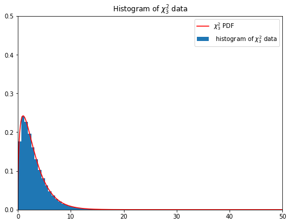

```python
import math
import numpy as np
import matplotlib.pyplot as plt
%matplotlib inline
from scipy import stats
"""
Imagine that you are trying to hit the target (0,0,0) in the 3D space.
Let (X,Y,Z) is the location that you hit then, assume that errors you make
in each direction are independent and normally distributed with mean 0 and variance 1
that is  x-cordinate error X-0=X, y-cordinate error Y-0=Y, and z-cordinate error Z-0=Z,
are distributed independetly and normally with mean 0   and variance 1.
Then (error)^2=(distance between target and location that you hit)^2 = (X-0)^2+(Y-0)^2+(Z-0)^2=X^2+Y^2+Z^2

"""
Infty =50
t=np.linspace(0,Infty,1000)
Chi2 = stats.chi2(3)
# Three independent satndard normal random variables X,Y,Z
X,Y,Z = (stats.norm(0, 1),stats.norm(0, 1),stats.norm(0, 1))

# Generating data for 1 million attempts to hit a target
(x,y,z)=(X.rvs(1000000),Y.rvs(1000000),Z.rvs(1000000))

# error2= dist((0,0,0),(x,y,z))^2 :
#which is kind of square of error that you are making when you try to hit the target

error2=x**2+y**2+z**2  # chi-squreed data of size 1000000 with 3 degrees of freedom
plt.figure(figsize=(8,6))
plt.hist(error2,bins=50,density=True,label=r" histogram of $\chi^2_3$ data")
plt.plot(t,Chi2.pdf(t),c='r',label=r"$\chi^2_3$ PDF")
plt.title(r"Histogram of $\chi^2_3$ data" )
plt.xlim(0,50)
plt.ylim(0,0.5)
plt.legend()
plt.show()
```

**Problem:** Suppose that we are attempting to locate a target in three-dimensional space, and that the three coordinate errors(in meters) of the point chosen are independent normal random variables with mean 0 and standard deviation 2. Find the probability that the distance between the point chosen and target exceeds 3 meters.

*solution:* Let $D$ denote the distance, and $X_i$ denote the error in the $i^{th}$ coordinate and $X_i\sim N(0,4)$ for $i=1,2,3$

then $D^2=X_1^2 +X_2^2 +X_3^2$

Take $Zi=\frac{X_i - 0}{2}=\frac{X_i}{2}\sim N(0,1)$ for $i=1,2,3$ and $Z_1^2+Z_2^2+Z_3^2=\chi^2_3$

$P(D>3)=P(D^2>9)=P(X_1^2 +X_2^2 +X_3^2 >9)=P(Z_1^2+Z_2^2+Z_3^2 >9/4)$

$=P(\chi^2_3 >2.25)=1-P(\chi^2_3 \le 2.25)=1-F_{\chi^2_3}(2.25)=0.5222$ ($\because~$ stats.chi2(3).cdf(2.25)= 0.47783281046460857)